# RH Analytics

# 1 Objetivos

- Número de variáveis: 18
- Tipo de variáveis
  - - Inteiras ou discretas:
  - - Numéricas ou double
  - - Categóricas
  - - Qualitativas
- Qualidade dos dados
  - - Quantidade de NA’s por variável
- Criação de novas variáveis, se precisar
- Transformação das variáveis, se precisar

# 2 Lendo os Conjuntos de Dados

```r
reticulate::source_python("../pickle_reader.py")
df.train <- read_pickle_file("../dataset/base_treinamento_testes.pkl") %>%
                                          data.frame(stringsAsFactors = F)

df.sub <- read_pickle_file("../dataset/base_submission.pkl") %>%
                                            data.frame(stringsAsFactors = F)
```

## 2.1 Base de treinamento

```r
df.train %>% head(10)
```

|  | codigo_vaga | ultimo_salario_candidato | ultimo_cargo_candidato | area_interesse_candidato | nivel_candidato | formacao_candidato | cidade_candidato | nivel_ingles_candidato | nivel_espanhol_candidato | mediana_teste_ingles_candidato | mediana_teste_espanhol_candidato | mediana_teste_logica_candidato | mediana_teste_outros_candidato | cargo_vaga | nivel_vaga | formacao_vaga | cidade_vaga | aprovado_vaga |
| --- | --- | --- | --- | --- | --- | --- | --- | --- | --- | --- | --- | --- | --- | --- | --- | --- | --- | --- |
| 4146 | -5.433147e+18 | 0 | INDUSTRIAL TRAINEE |  |  | POS-GRADUACAO NO NIVEL ESPECIALIZACAO |  | 2 | 1 | 6.450 | 0.000 | 6.250 | 7.00 |  | JUNIOR/TRAINEE | FORMACAO SUPERIOR (CURSANDO) |  | 0 |
| 4147 | -5.433147e+18 | 1500 | DESENVOLVIMENTO ENGENHEIRO PRO |  |  | FORMACAO SUPERIOR COMPLETA |  | 4 | 1 | 8.000 | 0.000 | 7.990 | 8.20 |  | JUNIOR/TRAINEE | FORMACAO SUPERIOR (CURSANDO) |  | 0 |
| 4148 | -5.433147e+18 | 2050 | CLIENTE ESTAGIO QUALIDADE |  |  | FORMACAO SUPERIOR COMPLETA |  | 2 | 0 | 3.875 | 0.000 | 5.330 | 5.40 |  | JUNIOR/TRAINEE | FORMACAO SUPERIOR (CURSANDO) |  | 0 |
| 4149 | -5.433147e+18 | 0 | CONTA EXECUTIVO PARCERIA |  |  | FORMACAO SUPERIOR COMPLETA |  | 3 | 0 | 7.250 | 0.000 | 7.990 | 6.25 |  | JUNIOR/TRAINEE | FORMACAO SUPERIOR (CURSANDO) |  | 0 |
| 4150 | -5.433147e+18 | 1890 | CICLO PDCA |  |  | POS-GRADUACAO NO NIVEL ESPECIALIZACAO |  | 3 | 4 | 5.250 | 6.375 | 6.650 | 7.00 |  | JUNIOR/TRAINEE | FORMACAO SUPERIOR (CURSANDO) |  | 0 |
| 4151 | -5.433147e+18 | 3400 | ANALISTA CUSTOMER SERVICE |  |  | FORMACAO SUPERIOR COMPLETA |  | 3 | 0 | 4.500 | 0.000 | 5.000 | 6.00 |  | JUNIOR/TRAINEE | FORMACAO SUPERIOR (CURSANDO) |  | 0 |
| 4152 | -5.433147e+18 | 1500 | AMBIENTAL ANALISTA AUXILIAR |  |  | POS-GRADUACAO NO NIVEL ESPECIALIZACAO |  | 2 | 0 | 3.000 | 0.000 | 5.990 | 2.85 |  | JUNIOR/TRAINEE | FORMACAO SUPERIOR (CURSANDO) |  | 0 |
| 4153 | -5.433147e+18 | 1253 | ESTAGIO |  |  | POS-GRADUACAO NO NIVEL ESPECIALIZACAO |  | 3 | 1 | 4.625 | 0.000 | 7.835 | 4.90 |  | JUNIOR/TRAINEE | FORMACAO SUPERIOR (CURSANDO) |  | 0 |
| 4154 | -5.433147e+18 | 4500 | ANALISTA CORPORATIVO HUMANOS R |  |  | POS-GRADUACAO NO NIVEL ESPECIALIZACAO |  | 4 | 1 | 7.625 | 0.000 | 8.050 | 7.60 |  | JUNIOR/TRAINEE | FORMACAO SUPERIOR (CURSANDO) |  | 0 |
| 4155 | -5.433147e+18 | 0 | APRENDIZ ESTAGIO |  |  | FORMACAO SUPERIOR COMPLETA |  | 0 | 0 | 0.000 | 0.000 | 0.000 | 3.10 |  | JUNIOR/TRAINEE | FORMACAO SUPERIOR (CURSANDO) |  | 0 |

## 2.2 Base de Submissão

```r
df.sub %>% head(10)
```

|  | codigo_vaga | ultimo_salario_candidato | ultimo_cargo_candidato | area_interesse_candidato | nivel_candidato | formacao_candidato | cidade_candidato | nivel_ingles_candidato | nivel_espanhol_candidato | mediana_teste_ingles_candidato | mediana_teste_espanhol_candidato | mediana_teste_logica_candidato | mediana_teste_outros_candidato | cargo_vaga | nivel_vaga | formacao_vaga | cidade_vaga |
| --- | --- | --- | --- | --- | --- | --- | --- | --- | --- | --- | --- | --- | --- | --- | --- | --- | --- |
| 0 | -5.432475e+18 | 9100 | GLOBAL TRAINEE |  |  | FORMACAO SUPERIOR COMPLETA |  | 4 | 0 | 7.000 | 0.00 | 7.335 | 7.00 |  | JUNIOR/TRAINEE | FORMACAO SUPERIOR (CURSANDO) |  |
| 1 | -5.432475e+18 | 7653 | TRADE |  |  | POS-GRADUACAO NO NIVEL ESPECIALIZACAO |  | 4 | 3 | 8.000 | 7.50 | 6.670 | 7.00 |  | JUNIOR/TRAINEE | FORMACAO SUPERIOR (CURSANDO) |  |
| 2 | -5.432475e+18 | 1978 | CONTROLADOR PRODUCAO |  |  | FORMACAO SUPERIOR COMPLETA |  | 3 | 0 | 4.750 | 6.75 | 7.340 | 7.40 |  | JUNIOR/TRAINEE | FORMACAO SUPERIOR (CURSANDO) |  |
| 3 | -5.432475e+18 | 0 | CONSULTOR EMPRESARIAL |  |  | FORMACAO SUPERIOR COMPLETA |  | 4 | 1 | 8.000 | 0.00 | 7.500 | 8.50 |  | JUNIOR/TRAINEE | FORMACAO SUPERIOR (CURSANDO) |  |
| 4 | -5.432475e+18 | 2100 | INFORMATICA REDE TECNICO |  |  | FORMACAO SUPERIOR COMPLETA |  | 1 | 0 | 3.010 | 3.25 | 3.330 | 4.00 |  | JUNIOR/TRAINEE | FORMACAO SUPERIOR (CURSANDO) |  |
| 5 | -5.432475e+18 | 2100 | ADMINISTRATIVO |  |  | FORMACAO SUPERIOR (CURSANDO) |  | 3 | 2 | 3.375 | 4.25 | 5.990 | 4.50 |  | JUNIOR/TRAINEE | FORMACAO SUPERIOR (CURSANDO) |  |
| 6 | -5.432475e+18 | 2000 | ADMINISTRATIVO COORDENADOR |  |  | FORMACAO SUPERIOR COMPLETA |  | 3 | 1 | 5.000 | 0.00 | 5.980 | 6.40 |  | JUNIOR/TRAINEE | FORMACAO SUPERIOR (CURSANDO) |  |
| 7 | -5.432475e+18 | 0 | FORMACAO INSTRUTOR PROFISSIONA |  |  | FORMACAO SUPERIOR COMPLETA |  | 2 | 1 | 0.000 | 0.00 | 0.000 | 8.75 |  | JUNIOR/TRAINEE | FORMACAO SUPERIOR (CURSANDO) |  |
| 8 | -5.432475e+18 | 0 | ANALISTA LOGISTICA |  |  | POS-GRADUACAO NO NIVEL ESPECIALIZACAO |  | 0 | 0 | 0.000 | 0.00 | 0.000 | 5.10 |  | JUNIOR/TRAINEE | FORMACAO SUPERIOR (CURSANDO) |  |
| 9 | -5.432475e+18 | 2200 | ACABAMENTO OPERADOR |  |  | POS-GRADUACAO NO NIVEL ESPECIALIZACAO |  | 0 | 0 | 0.000 | 0.00 | 0.000 | 5.15 |  | JUNIOR/TRAINEE | FORMACAO SUPERIOR (CURSANDO) |  |

Adicionando a variável **aprovado_vaga** na base de submissão.

```r
df.sub$aprovado_vaga <- NA
df.sub %>% head(20)
```

|  | codigo_vaga | ultimo_salario_candidato | ultimo_cargo_candidato | area_interesse_candidato | nivel_candidato | formacao_candidato | cidade_candidato | nivel_ingles_candidato | nivel_espanhol_candidato | mediana_teste_ingles_candidato | mediana_teste_espanhol_candidato | mediana_teste_logica_candidato | mediana_teste_outros_candidato | cargo_vaga | nivel_vaga | formacao_vaga | cidade_vaga | aprovado_vaga |
| --- | --- | --- | --- | --- | --- | --- | --- | --- | --- | --- | --- | --- | --- | --- | --- | --- | --- | --- |
| 0 | -5.432475e+18 | 9100 | GLOBAL TRAINEE |  |  | FORMACAO SUPERIOR COMPLETA |  | 4 | 0 | 7.000 | 0.00 | 7.335 | 7.00 |  | JUNIOR/TRAINEE | FORMACAO SUPERIOR (CURSANDO) |  | NA |
| 1 | -5.432475e+18 | 7653 | TRADE |  |  | POS-GRADUACAO NO NIVEL ESPECIALIZACAO |  | 4 | 3 | 8.000 | 7.50 | 6.670 | 7.00 |  | JUNIOR/TRAINEE | FORMACAO SUPERIOR (CURSANDO) |  | NA |
| 2 | -5.432475e+18 | 1978 | CONTROLADOR PRODUCAO |  |  | FORMACAO SUPERIOR COMPLETA |  | 3 | 0 | 4.750 | 6.75 | 7.340 | 7.40 |  | JUNIOR/TRAINEE | FORMACAO SUPERIOR (CURSANDO) |  | NA |
| 3 | -5.432475e+18 | 0 | CONSULTOR EMPRESARIAL |  |  | FORMACAO SUPERIOR COMPLETA |  | 4 | 1 | 8.000 | 0.00 | 7.500 | 8.50 |  | JUNIOR/TRAINEE | FORMACAO SUPERIOR (CURSANDO) |  | NA |
| 4 | -5.432475e+18 | 2100 | INFORMATICA REDE TECNICO |  |  | FORMACAO SUPERIOR COMPLETA |  | 1 | 0 | 3.010 | 3.25 | 3.330 | 4.00 |  | JUNIOR/TRAINEE | FORMACAO SUPERIOR (CURSANDO) |  | NA |
| 5 | -5.432475e+18 | 2100 | ADMINISTRATIVO |  |  | FORMACAO SUPERIOR (CURSANDO) |  | 3 | 2 | 3.375 | 4.25 | 5.990 | 4.50 |  | JUNIOR/TRAINEE | FORMACAO SUPERIOR (CURSANDO) |  | NA |
| 6 | -5.432475e+18 | 2000 | ADMINISTRATIVO COORDENADOR |  |  | FORMACAO SUPERIOR COMPLETA |  | 3 | 1 | 5.000 | 0.00 | 5.980 | 6.40 |  | JUNIOR/TRAINEE | FORMACAO SUPERIOR (CURSANDO) |  | NA |
| 7 | -5.432475e+18 | 0 | FORMACAO INSTRUTOR PROFISSIONA |  |  | FORMACAO SUPERIOR COMPLETA |  | 2 | 1 | 0.000 | 0.00 | 0.000 | 8.75 |  | JUNIOR/TRAINEE | FORMACAO SUPERIOR (CURSANDO) |  | NA |
| 8 | -5.432475e+18 | 0 | ANALISTA LOGISTICA |  |  | POS-GRADUACAO NO NIVEL ESPECIALIZACAO |  | 0 | 0 | 0.000 | 0.00 | 0.000 | 5.10 |  | JUNIOR/TRAINEE | FORMACAO SUPERIOR (CURSANDO) |  | NA |
| 9 | -5.432475e+18 | 2200 | ACABAMENTO OPERADOR |  |  | POS-GRADUACAO NO NIVEL ESPECIALIZACAO |  | 0 | 0 | 0.000 | 0.00 | 0.000 | 5.15 |  | JUNIOR/TRAINEE | FORMACAO SUPERIOR (CURSANDO) |  | NA |

[output cut: 10 more lines]

## 2.3 Unindo as bases

Agora vou juntar as bases de treinamento e submissão para tratar os dados de forma uniforme.

```r
df.all <- rbind(df.train,df.sub)
```

## 2.4 Há quantos tipo de dados ?

```r
lapply(df.all,class) %>%
                unlist %>%
          as.character %>%
                 table
```

```
## .
## character      list   numeric
##         4         5         9
```

Quais são essas colunas com o tipo de dados lista?

## 2.5 Colunas com tipo de dados **list**.

```r
df.all[,lapply(df.all,class) == 'list'] %>% head()
```

|  | area_interesse_candidato | nivel_candidato | cidade_candidato | cargo_vaga | cidade_vaga |
| --- | --- | --- | --- | --- | --- |
| 4146 |  |  |  |  |  |
| 4147 |  |  |  |  |  |
| 4148 |  |  |  |  |  |
| 4149 |  |  |  |  |  |
| 4150 |  |  |  |  |  |
| 4151 |  |  |  |  |  |

### 2.5.1 Recuperando as informações das colunas com tipo de dados **list**.

```r
df.all[,lapply(df.all,class) == 'list'] <- df.all[,lapply(df.all,class) == 'list'] %>%
                                                                    lapply('as.character') %>%
                                                                    data.frame()
```

E agora como estão os metadados?

```r
lapply(df.all,class) %>%
                unlist %>%
          as.character %>%
                 table
```

```
## .
## character    factor   numeric
##         4         5         9
```

## 2.6 Analisando as colunas pelo tipo de dados.

### 2.6.1 Tipo de dado String

```r
df.all[,lapply(df.all,class) == 'character'] %>% head()
```

|  | ultimo_cargo_candidato | formacao_candidato | nivel_vaga | formacao_vaga |
| --- | --- | --- | --- | --- |
| 4146 | INDUSTRIAL TRAINEE | POS-GRADUACAO NO NIVEL ESPECIALIZACAO | JUNIOR/TRAINEE | FORMACAO SUPERIOR (CURSANDO) |
| 4147 | DESENVOLVIMENTO ENGENHEIRO PRO | FORMACAO SUPERIOR COMPLETA | JUNIOR/TRAINEE | FORMACAO SUPERIOR (CURSANDO) |
| 4148 | CLIENTE ESTAGIO QUALIDADE | FORMACAO SUPERIOR COMPLETA | JUNIOR/TRAINEE | FORMACAO SUPERIOR (CURSANDO) |
| 4149 | CONTA EXECUTIVO PARCERIA | FORMACAO SUPERIOR COMPLETA | JUNIOR/TRAINEE | FORMACAO SUPERIOR (CURSANDO) |
| 4150 | CICLO PDCA | POS-GRADUACAO NO NIVEL ESPECIALIZACAO | JUNIOR/TRAINEE | FORMACAO SUPERIOR (CURSANDO) |
| 4151 | ANALISTA CUSTOMER SERVICE | FORMACAO SUPERIOR COMPLETA | JUNIOR/TRAINEE | FORMACAO SUPERIOR (CURSANDO) |

Vamos transformar o tipo de dados dessas variáveis de string para categóricas.

```r
df.all[,lapply(df.all,class) == 'character'] = df.all[,lapply(df.all,class) == 'character'] %>%
                                                                                    apply(2,factor) %>%
                                                                   data.frame(stringsAsFactors = T)
```

Aproveito para converter o tipo de dado da variável aprovado_vaga, tipo inteiro, para categórico.

```r
df.all$aprovado_vaga <- as.factor(df.all$aprovado_vaga)
```

E agora, quais são os tipo de dados no data-frame ?

```r
lapply(df.all,class) %>%
                unlist %>%
          as.character %>%
                 table
```

```
## .
##  factor numeric
##      10       8
```

overview das caracteríscas dos dados.

```r
str(df.all)
```

```
## 'data.frame':    52278 obs. of  18 variables:
##  $ codigo_vaga                     : num  -5.43e+18 -5.43e+18 -5.43e+18 -5.43e+18 -5.43e+18 ...
##  $ ultimo_salario_candidato        : num  0 1500 2050 0 1890 ...
##  $ ultimo_cargo_candidato          : Factor w/ 14002 levels "","ABANDONADO ANIMAL COM RESGATAD",..: 12148 9354 7182 8133 7064 2248 1308 10800 2178 3784 ...
##  $ area_interesse_candidato        : Factor w/ 118 levels "ADMINISTRACAO COMERCIAL/VENDAS",..: 44 2 39 67 67 1 85 44 88 74 ...
##  $ nivel_candidato                 : Factor w/ 10 levels "AUXILIAR/OPERACIONAL",..: 5 5 3 5 1 5 1 3 7 3 ...
##  $ formacao_candidato              : Factor w/ 9 levels "ENSINO FUNDAMENTAL (1O. GRAU) INTERROMPIDO",..: 8 5 5 5 8 5 8 8 8 5 ...
##  $ cidade_candidato                : Factor w/ 1827 levels "4 DE NOVIEMBRE",..: 1392 1538 117 1538 1538 1538 1695 1490 1538 1157 ...
##  $ nivel_ingles_candidato          : num  2 4 2 3 3 3 2 3 4 0 ...
##  $ nivel_espanhol_candidato        : num  1 1 0 0 4 0 0 1 1 0 ...
##  $ mediana_teste_ingles_candidato  : num  6.45 8 3.88 7.25 5.25 ...
##  $ mediana_teste_espanhol_candidato: num  0 0 0 0 6.38 ...
##  $ mediana_teste_logica_candidato  : num  6.25 7.99 5.33 7.99 6.65 ...
##  $ mediana_teste_outros_candidato  : num  7 8.2 5.4 6.25 7 ...
##  $ cargo_vaga                      : Factor w/ 10 levels "COMERCIAL","COORDENADOR PROGRAMA",..: 7 7 7 7 7 7 7 7 7 7 ...
##  $ nivel_vaga                      : Factor w/ 1 level "JUNIOR/TRAINEE": 1 1 1 1 1 1 1 1 1 1 ...
##  $ formacao_vaga                   : Factor w/ 2 levels "FORMACAO SUPERIOR (CURSANDO)",..: 1 1 1 1 1 1 1 1 1 1 ...
##  $ cidade_vaga                     : Factor w/ 8 levels "CURITIBA","GUADALAJARA",..: 5 5 5 5 5 5 5 5 5 5 ...
##  $ aprovado_vaga                   : Factor w/ 2 levels "0","1": 1 1 1 1 1 1 1 1 1 1 ...
```

### 2.6.2 Tipo de dado Categórico

```r
df.fator <- df.all[,lapply(df.all,class) == 'factor']
```

informações resumida dos dados.

```r
df.fator %>%
      summary
```

```
##                ultimo_cargo_candidato
##  ESTAGIO                  : 4327
##  NAO CLASSIFICADO         : 1270
##  TRAINEE                  :  763
##  CONSULTOR                :  619
##  ANALISTA                 :  588
##  ADMINISTRATIVO ASSISTENTE:  549
##  (Other)                  :44162
##                    area_interesse_candidato               nivel_candidato
##  NULL                          : 9231       JUNIOR/TRAINEE        :13302
##  ENGENHARIA DE PRODUCAO        : 4217       ESTAGIO               :11728
##  ADMINISTRACAO COMERCIAL/VENDAS: 4117       PLENO                 : 9719
##  ENGENHARIA - OUTRAS           : 3015       AUXILIAR/OPERACIONAL  : 5691
##  ENGENHARIA MECANICA           : 2814       SUPERVISAO/COORDENACAO: 4417
##  ADMINISTRACAO DE EMPRESAS     : 2610       TECNICO               : 1996
##  (Other)                       :26274       (Other)               : 5425
##                              formacao_candidato         cidade_candidato
##  FORMACAO SUPERIOR COMPLETA           :35453    SAO PAULO       :11372
##  POS-GRADUACAO NO NIVEL ESPECIALIZACAO: 8509    RIO DE JANEIRO  : 4099
##  FORMACAO SUPERIOR (CURSANDO)         : 5195    BELO HORIZONTE  : 2500
##  POS-GRADUACAO NO NIVEL MESTRADO      : 2965    LIMA            : 1757
##  POS-GRADUACAO NO NIVEL DOUTORADO     :  112    CAMPINAS        : 1560
##  ENSINO MEDIO (2O. GRAU) COMPLETO     :   18    CIUDAD DE MEXICO: 1305
##  (Other)                              :   26    (Other)         :29685
##                      cargo_vaga             nivel_vaga
##  NULL                     :20736   JUNIOR/TRAINEE:52278
##  PROGRAMA TRAINEE         :20027
##  CORPORATIVO TRAINEE      : 2694
##  COORDENADOR PROGRAMA     : 2565
##  GERENTE LOJA SUPERMERCADO: 1835
##  INTERNACIONAL TRAINEE    : 1753
##  (Other)                  : 2668
##                       formacao_vaga       cidade_vaga    aprovado_vaga
##  FORMACAO SUPERIOR (CURSANDO):48741   NULL      :38132   0   :23181
##  FORMACAO SUPERIOR COMPLETA  : 3537   PARANAGUA : 4146   1   : 2518
##                                       SAO PAULO : 2711   NA's:26579
##                                       INDAIATUBA: 2076
##                                       CURITIBA  : 1966
##                                       JUNDIAI   : 1442
##                                       (Other)   : 1805
```

- Observe que nas variáveis **area_interesse_candidato**, **cargo_vaga e cidade_vaga** há um números significativo de valores nulos, esses valores podem ser tratados por uma série de técnicas que vão desde o imput através de modelagem até a sua exclusão.
- Outro ponto, é o fato de a variável **nível_vaga** ter apenas 1 categoria **‘JUNIOR/TRAINEE’**, logo iremos excluí-la de nossa análise, pois com apenas uma categoria ou valor qualquer variável não nos fornece informações relevantes.
- As categorias da variável de interesse estão desbalanceadas, observe que o número de eventos para a categoria 1 é um pouco maior que 10% do número de eventos da categoria 0, isto implica que pode ser necessário algum processo de amostragem para atingir uma performance razoável como output do processo de modelagem.

### 2.6.3 Tipo de Dado Numérico

```r
df.num <- df.all[,lapply(df.all,class) == 'numeric']
df.num %>% head()
```

|  | codigo_vaga | ultimo_salario_candidato | nivel_ingles_candidato | nivel_espanhol_candidato | mediana_teste_ingles_candidato | mediana_teste_espanhol_candidato | mediana_teste_logica_candidato | mediana_teste_outros_candidato |
| --- | --- | --- | --- | --- | --- | --- | --- | --- |
| 4146 | -5.433147e+18 | 0 | 2 | 1 | 6.450 | 0.000 | 6.25 | 7.00 |
| 4147 | -5.433147e+18 | 1500 | 4 | 1 | 8.000 | 0.000 | 7.99 | 8.20 |
| 4148 | -5.433147e+18 | 2050 | 2 | 0 | 3.875 | 0.000 | 5.33 | 5.40 |
| 4149 | -5.433147e+18 | 0 | 3 | 0 | 7.250 | 0.000 | 7.99 | 6.25 |
| 4150 | -5.433147e+18 | 1890 | 3 | 4 | 5.250 | 6.375 | 6.65 | 7.00 |
| 4151 | -5.433147e+18 | 3400 | 3 | 0 | 4.500 | 0.000 | 5.00 | 6.00 |

### 2.6.4 Resumo dos dados numéricos

```r
summary(df.num)
```

```
##   codigo_vaga         ultimo_salario_candidato nivel_ingles_candidato
##  Min.   :-8.852e+18   Min.   :      0          Min.   :0.000
##  1st Qu.:-5.432e+18   1st Qu.:      0          1st Qu.:2.000
##  Median :-3.218e+18   Median :   1300          Median :3.000
##  Mean   :-1.428e+18   Mean   :   3805          Mean   :2.597
##  3rd Qu.: 1.222e+18   3rd Qu.:   3000          3rd Qu.:4.000
##  Max.   : 9.035e+18   Max.   :9000000          Max.   :4.000
##  nivel_espanhol_candidato mediana_teste_ingles_candidato
##  Min.   :0.00             Min.   : 0.000
##  1st Qu.:0.00             1st Qu.: 1.075
##  Median :1.00             Median : 5.630
##  Mean   :1.02             Mean   : 4.653
##  3rd Qu.:2.00             3rd Qu.: 7.170
##  Max.   :4.00             Max.   :10.000
##  mediana_teste_espanhol_candidato mediana_teste_logica_candidato
##  Min.   : 0.0000                  Min.   : 0.000
##  1st Qu.: 0.0000                  1st Qu.: 3.000
##  Median : 0.0000                  Median : 5.990
##  Mean   : 0.9488                  Mean   : 4.896
##  3rd Qu.: 0.0000                  3rd Qu.: 7.250
##  Max.   :10.0000                  Max.   :10.000
##  mediana_teste_outros_candidato
##  Min.   : 0.000
##  1st Qu.: 4.250
##  Median : 6.200
##  Mean   : 5.524
##  3rd Qu.: 7.500
##  Max.   :10.000
```

De forma geral os valores dessas variáveis apresentam um comportamento bem distribuído em torno de sua média/mediana e isso ajuda bastante no processo de convergência para a(s) estimativa(s) dos valore(s) dos parâmetro(s) que cada método de aprendizagem dispoe. No entanto, as variáveis **ultimo_salario_candidato** e **mediana_teste_espanhol_candidato** apresentam pontos que estão de certa forma distantes de suas médias/mediana podendo causar assimetria em seus comportamentos e como consequência uma certa dificuldade em se realizar predições sobre eles.

Os pontos extremos, outliers, muitas vezes são retirados dos conjuntos de dados de forma equivocada e quando isso ocorre o modelo passa a não representar a realidade do evento de interesse limitando-se a predições compreendidas dentro de um range menor de valores o que certamente prejudica a tomada de decisão.

## 2.7 A variável **codigo_vaga**

Será que podemos transformar os códigos desssas vagas em categorias? Afinal, há quantos códigos de vagas?

```r
table(df.num$codigo_vaga)
```

```
##
## -8851622128430865408 -8665149857608157184 -8121008623955203072
##                 1442                  323                  774
## -7433230746669201408 -6387918047679570944 -5433147389500582912
##                  734                 3539                 2851
## -5432475023076753408 -4680893303693323264 -4540071236086954496
##                 4146                 5855                 2565
## -3926712961740574720 -3218332895185976832 -3139734604785841664
##                 2694                 1365                 1492
## -2894132490890953216 -1872122770023579648  -408011488522086592
##                  232                 1127                  276
##  -328337796252815616  1167184937340811264  1221578433373216768
##                  912                 8402                 3791
##  3432259187290165760  3773628003473435648  4005443819117183488
##                  702                 2076                 1218
##  5837574494153107456  7173759003647469568  8194206283447659520
##                  928                 1519                  440
##  8670946023719118848  8869708662086094848  9034887193305818112
##                  593                  447                 1835
```

veja que interessante há 27 códigos diferentes, iremos substituí-los por letras e converter esta variável em categórica.

```r
set.seed(497)
df.num$codigo_vaga <- as.character(df.num$codigo_vaga)
(codigos <- data.frame(codigos = df.num$codigo_vaga %>%
                                              table %>%
                                               names,
                       letras = as.character(c(LETTERS[1:26],
                                               paste(LETTERS[1:2],
                                                     collapse = ""))),
                                stringsAsFactors = F))
```

| codigos | letras |
| --- | --- |
| -1872122770023579648 | A |
| -2894132490890953216 | B |
| -3139734604785841664 | C |
| -3218332895185976832 | D |
| -328337796252815616 | E |
| -3926712961740574720 | F |
| -408011488522086592 | G |
| -4540071236086954496 | H |
| -4680893303693323264 | I |
| -5432475023076753408 | J |

[output cut: 17 more lines]

substituindo os códigos da variável **codigo_vaga** por letras.

```r
for(i in 1:nrow(codigos)) df.num[df.num$codigo_vaga == codigos[i,1],'codigo_vaga'] <- as.character(codigos[i,2])
```

```r
df.num %>% head
```

|  | codigo_vaga | ultimo_salario_candidato | nivel_ingles_candidato | nivel_espanhol_candidato | mediana_teste_ingles_candidato | mediana_teste_espanhol_candidato | mediana_teste_logica_candidato | mediana_teste_outros_candidato |
| --- | --- | --- | --- | --- | --- | --- | --- | --- |
| 4146 | K | 0 | 2 | 1 | 6.450 | 0.000 | 6.25 | 7.00 |
| 4147 | K | 1500 | 4 | 1 | 8.000 | 0.000 | 7.99 | 8.20 |
| 4148 | K | 2050 | 2 | 0 | 3.875 | 0.000 | 5.33 | 5.40 |
| 4149 | K | 0 | 3 | 0 | 7.250 | 0.000 | 7.99 | 6.25 |
| 4150 | K | 1890 | 3 | 4 | 5.250 | 6.375 | 6.65 | 7.00 |
| 4151 | K | 3400 | 3 | 0 | 4.500 | 0.000 | 5.00 | 6.00 |

## 2.8 Dados Categóricos + Numéricos

```r
df.all = bind_cols(df.fator,df.num) %>%
         select(aprovado_vaga,codigo_vaga, everything()) %>%
            data.frame(stringsAsFactors = T)
```

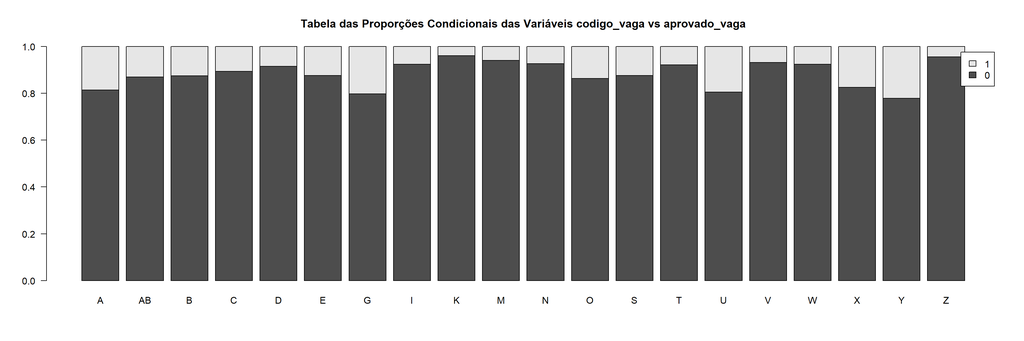

```r
xtabs( ~ aprovado_vaga + codigo_vaga,
           data = df.all[!is.na(df.all$aprovado_vaga),]) %>%
           prop.table(2) %>%
           barplot(legend = T, horiz = F, las = 1, main = '\n Tabela das Proporções Condicionais das Variáveis codigo_vaga vs aprovado_vaga \n')
```

Observe no gráfico acima que dependendo do código da vaga em que o candidado se inscrever ele terá maior ou menor chance de ser aprovado, esta variável poderá nos ajudar a discriminar a variável resposta **aprovado_vaga**.

## 2.9 Resumo dos dados

```r
skim_to_wide(df.all)
```

| type | variable | missing | complete | n | min | max | empty | n_unique | top_counts | ordered | mean | sd | p0 | p25 | p50 | p75 | p100 | hist |
| --- | --- | --- | --- | --- | --- | --- | --- | --- | --- | --- | --- | --- | --- | --- | --- | --- | --- | --- |
| character | codigo_vaga | 0 | 52278 | 52278 | 1 | 2 | 0 | 27 | NA | NA | NA | NA | NA | NA | NA | NA | NA | NA |
| factor | aprovado_vaga | 26579 | 25699 | 52278 | NA | NA | NA | 2 | NA: 26579, 0: 23181, 1: 2518 | FALSE | NA | NA | NA | NA | NA | NA | NA | NA |
| factor | area_interesse_candidato | 0 | 52278 | 52278 | NA | NA | NA | 118 | NUL: 9231, ENG: 4217, ADM: 4117, ENG: 3015 | FALSE | NA | NA | NA | NA | NA | NA | NA | NA |
| factor | cargo_vaga | 0 | 52278 | 52278 | NA | NA | NA | 10 | NUL: 20736, PRO: 20027, COR: 2694, COO: 2565 | FALSE | NA | NA | NA | NA | NA | NA | NA | NA |
| factor | cidade_candidato | 0 | 52278 | 52278 | NA | NA | NA | 1827 | SAO: 11372, RIO: 4099, BEL: 2500, LIM: 1757 | FALSE | NA | NA | NA | NA | NA | NA | NA | NA |
| factor | cidade_vaga | 0 | 52278 | 52278 | NA | NA | NA | 8 | NUL: 38132, PAR: 4146, SAO: 2711, IND: 2076 | FALSE | NA | NA | NA | NA | NA | NA | NA | NA |
| factor | formacao_candidato | 0 | 52278 | 52278 | NA | NA | NA | 9 | FOR: 35453, POS: 8509, FOR: 5195, POS: 2965 | FALSE | NA | NA | NA | NA | NA | NA | NA | NA |
| factor | formacao_vaga | 0 | 52278 | 52278 | NA | NA | NA | 2 | FOR: 48741, FOR: 3537, NA: 0 | FALSE | NA | NA | NA | NA | NA | NA | NA | NA |
| factor | nivel_candidato | 0 | 52278 | 52278 | NA | NA | NA | 10 | JUN: 13302, EST: 11728, PLE: 9719, AUX: 5691 | FALSE | NA | NA | NA | NA | NA | NA | NA | NA |
| factor | nivel_vaga | 0 | 52278 | 52278 | NA | NA | NA | 1 | JUN: 52278, NA: 0 | FALSE | NA | NA | NA | NA | NA | NA | NA | NA |

[output cut: 8 more lines]

```r
df.all$codigo_vaga <- as.factor(df.all$codigo_vaga)
```

Qual a importância de cada variável em relação a variável resposta.

## 2.10 Importância das Variáveis

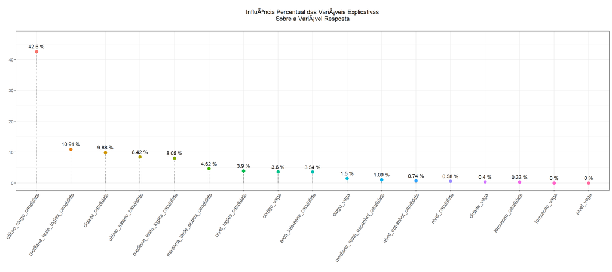

```r
importance.vars(df.all,'aprovado_vaga')
```

Aqui temos uma idéia prévia das variáveis que poderão fazer parte do modelo, veja que as variáveis **ultimo_cargo_candidato**, **mediana_teste_ingles_candidato**, **cidade_candidato** podem contribuir significativamente para nos ajudar a explicar o comportamento da variável resposta.

## 2.11 Número de Categoria das Variáveis

```r
apply(df.all,2,function(x) length(table(x))) %>% sort(decreasing = T)
```

```
##           ultimo_cargo_candidato         ultimo_salario_candidato
##                            14002                             2603
##                 cidade_candidato   mediana_teste_ingles_candidato
##                             1827                             1295
##   mediana_teste_logica_candidato   mediana_teste_outros_candidato
##                             1174                              581
## mediana_teste_espanhol_candidato         area_interesse_candidato
##                              138                              118
##                      codigo_vaga                  nivel_candidato
##                               27                               10
##                       cargo_vaga               formacao_candidato
##                               10                                9
##                      cidade_vaga           nivel_ingles_candidato
##                                8                                5
##         nivel_espanhol_candidato                    aprovado_vaga
##                                5                                2
##                    formacao_vaga                       nivel_vaga
##                                2                                1
```

Note que as variáveis **ultimo_cargo_candidato**, **cidade_candidato**, **area_interesse_candidato** possuem muitas categorias e isto pode ser um problema quando formos realizar a modelagem, vamos analisá-las.

## 2.12 Variável **ultimo_cargo_candidato**

Quais são as categorias da variável **ultimo_cargo_candidato**?

```r
df.all$ultimo_cargo_candidato %>%
                        table %>%
         sort(decreasing = T) %>%
                     head(50)
```

```
## .
##                     ESTAGIO            NAO CLASSIFICADO
##                        4327                        1270
##                     TRAINEE                   CONSULTOR
##                         763                         619
##                    ANALISTA   ADMINISTRATIVO ASSISTENTE
##                         588                         549
##            CIVIL ENGENHEIRO     ADMINISTRATIVO AUXILIAR
##                         480                         478
##         ANALISTA FINANCEIRO                   PROFESSOR
##                         382                         332
##            ANALISTA PROJETO         ENGENHEIRO MECANICO
##                         312                         272
##                  ENGENHEIRO          ANALISTA MARKETING
##                         260                         227
##            ANALISTA NEGOCIO          ANALISTA COMERCIAL
##                         219                         216
##           ANALISTA PROCESSO                    ADVOGADO
##                         210                         207
##          ENGENHARIA ESTAGIO     ADMINISTRATIVO ANALISTA
##                         205                         194
##            ANALISTA ESTAGIO           ACADEMICO ESTAGIO
##                         180                         174
##      ELETRICISTA ENGENHEIRO          ANALISTA LOGISTICA
##                         173                         168
##          ANALISTA QUALIDADE                   COMPRADOR
##                         158                         154
## ENGENHARIA ESTAGIO MECANICO       ANALISTA PLANEJAMENTO
##                         150                         149
##          ENGENHEIRO TRAINEE                    VENDEDOR
##                         149                         143
##            ANALISTA PRODUTO        ASSISTENTE COMERCIAL
##                         142                         139
##                 PESQUISADOR          AMBIENTAL ANALISTA
##                         138                         133
##    INGLESA LINGUA PROFESSOR         ENGENHEIRO PROCESSO
##                         132                         129
##            ANALISTA SISTEMA           ANALISTA OPERACAO
##                         128                         121
##       ASSISTENTE FINANCEIRO               ADMINISTRADOR
##                         116                         115
##                  PRATICANTE                  ASSISTENTE
##                         111                         107
##      ADMINISTRATIVO GERENTE          ENGENHEIRO PROJETO
##                         102                         102
##       AGENTE INOVACAO LOCAL                     AUDITOR
##                         101                          99
##            BOLSISTA ESTAGIO   ANALISTA HUMANOS RECURSOS
##                          97                          90
##         ASSISTENTE CONTABIL    CIVIL ENGENHARIA ESTAGIO
##                          88                          87
```

Com uma rápida olhada nestas categorias é possível observar que as palavras **ESTAGIO**, **ENGENHEIRO**, **ANALISTA**, **TRAINEE** entre outras são bastante frequentes, precisamos trata-las afim de reduzir o número de categorias desta variável.  
Agora vamos fazer um split em cada string da variável **ultimo_cargo_candidato** e por fim contar verficar as categorias mais frequentes.

```r
df.all$ultimo_cargo_candidato %>%
                 str_split(" ") %>%
                         unlist %>%
                        table() %>%
           sort(decreasing = T) %>%
                       head(50)
```

[output not shown]

criando uma variável.

```r
df.all$emprego <- NA
df.all$emprego <- as.character(df.all$emprego)
```

```r
(df.cargo <- readxl::read_excel('../dataset/ultimo_cargo.xlsx',sheet = 'Plan1'))
```

| categoria | nova_categoria |
| --- | --- |
| ANALISTA | ANALISTA |
| ASSISTENTE | ASSISTENTE |
| ENGENHEIRO | ENGENHEIRO |
| TRAINEE | TRAINEE |
| ADMINISTRATIVO | ADMINISTRATIVO |
| CONSULTOR | CONSULTOR |
| ENGENHARIA | ENGENHERIO |
| TECNICO | TECNICO |
| AUXILIAR | AUXILIAR |
| GERENTE | GESTOR |

[output cut: 68 more lines]

imputando as novas categorias referente ao último cargo do candidato.

```r
for(i in 1:nrow(df.cargo)){

  df.all[str_detect(as.character(df.all[,3]),as.character(df.cargo[i,1])),'emprego'] <- as.character(df.cargo[i,2])
}
```

```r
df.all %>%
  select(ultimo_cargo_candidato,emprego)
```

| ultimo_cargo_candidato | emprego |
| --- | --- |
| INDUSTRIAL TRAINEE | TRAINEE |
| DESENVOLVIMENTO ENGENHEIRO PRO | ENGENHEIRO |
| CLIENTE ESTAGIO QUALIDADE | ESTAGIARIO |
| CONTA EXECUTIVO PARCERIA | NA |
| CICLO PDCA | PESQUISADOR |
| ANALISTA CUSTOMER SERVICE | ANALISTA |
| AMBIENTAL ANALISTA AUXILIAR | AUXILIAR |
| ESTAGIO | ESTAGIARIO |
| ANALISTA CORPORATIVO HUMANOS R | ANALISTA |
| APRENDIZ ESTAGIO | ESTAGIARIO |

[output cut: 9990 more lines]

E agora ficamos com quantas categorias?

```r
df.all$emprego %>%
  table %>%
  sort(decreasing = T)
```

```
## .
##         ANALISTA       ESTAGIARIO       ENGENHEIRO           GESTOR
##             9084             8156             3416             3018
##       SUPERVISOR       ASSISTENTE        CONSULTOR   ADMINISTRATIVO
##             2834             2724             1888             1815
##          TRAINEE        PROFESSOR         AUXILIAR NAO CLASSIFICADO
##             1653             1494             1491             1270
##          TECNICO      PESQUISADOR         VENDEDOR       ENGENHERIO
##             1236              939              506              458
##     EMPREENDEDOR     ESPECIALISTA          AUDITOR    DESENVOLVEDOR
##              432              431              389              311
##         ADVOGADO         OPERADOR        COMPRADOR           MEDICO
##              296              264              237               62
##        ESTUDANTE
##               50
```

agora temos apenas 25 categorias, ocorre porém que este processo de redução das categorias implica em termos uma menor variabilidade da variável de interesse em relação a essas novas categoricas, o que de certa forma acaba prejudicando o desempenho dos modelos, o ideal é encontrar o número mínimo de categorias que maximizam a variabilidade da variável resposta.

```r
sum(df.all$emprego %>% is.na())/nrow(df.all)
```

```
## [1] 0.1496614
```

a categoria **OUTROS** irá representar as categorias menos frequentes.

```r
df.all$emprego[is.na(df.all$emprego)] <- 'OUTROS'
```

atribuindo as novas categorias a variável **ultimo_cargo_candidato**.

```r
df.all$ultimo_cargo_candidato <- df.all$emprego
```

deletando a variável emprego.

```r
df.all$emprego <- NULL
```

vejamos como ficou nosso dataframe.

```r
df.all %>% head()
```

|  | aprovado_vaga | codigo_vaga | ultimo_cargo_candidato | area_interesse_candidato | nivel_candidato | formacao_candidato | cidade_candidato | cargo_vaga | nivel_vaga | formacao_vaga | cidade_vaga | ultimo_salario_candidato | nivel_ingles_candidato | nivel_espanhol_candidato | mediana_teste_ingles_candidato | mediana_teste_espanhol_candidato | mediana_teste_logica_candidato | mediana_teste_outros_candidato |
| --- | --- | --- | --- | --- | --- | --- | --- | --- | --- | --- | --- | --- | --- | --- | --- | --- | --- | --- |
| 1 | 0 | K | TRAINEE | ENGENHARIA QUIMICA | JUNIOR/TRAINEE | POS-GRADUACAO NO NIVEL ESPECIALIZACAO | SALVADOR | PROGRAMA TRAINEE | JUNIOR/TRAINEE | FORMACAO SUPERIOR (CURSANDO) | NULL | 0 | 2 | 1 | 6.450 | 0.000 | 6.25 | 7.00 |
| 2 | 0 | K | ENGENHEIRO | ADMINISTRACAO DE EMPRESAS | JUNIOR/TRAINEE | FORMACAO SUPERIOR COMPLETA | SAO PAULO | PROGRAMA TRAINEE | JUNIOR/TRAINEE | FORMACAO SUPERIOR (CURSANDO) | NULL | 1500 | 4 | 1 | 8.000 | 0.000 | 7.99 | 8.20 |
| 3 | 0 | K | ESTAGIARIO | ENGENHARIA DE PRODUCAO | ESTAGIO | FORMACAO SUPERIOR COMPLETA | ARUJA | PROGRAMA TRAINEE | JUNIOR/TRAINEE | FORMACAO SUPERIOR (CURSANDO) | NULL | 2050 | 2 | 0 | 3.875 | 0.000 | 5.33 | 5.40 |
| 4 | 0 | K | OUTROS | MARKETING | JUNIOR/TRAINEE | FORMACAO SUPERIOR COMPLETA | SAO PAULO | PROGRAMA TRAINEE | JUNIOR/TRAINEE | FORMACAO SUPERIOR (CURSANDO) | NULL | 0 | 3 | 0 | 7.250 | 0.000 | 7.99 | 6.25 |
| 5 | 0 | K | PESQUISADOR | MARKETING | AUXILIAR/OPERACIONAL | POS-GRADUACAO NO NIVEL ESPECIALIZACAO | SAO PAULO | PROGRAMA TRAINEE | JUNIOR/TRAINEE | FORMACAO SUPERIOR (CURSANDO) | NULL | 1890 | 3 | 4 | 5.250 | 6.375 | 6.65 | 7.00 |
| 6 | 0 | K | ANALISTA | ADMINISTRACAO COMERCIAL/VENDAS | JUNIOR/TRAINEE | FORMACAO SUPERIOR COMPLETA | SAO PAULO | PROGRAMA TRAINEE | JUNIOR/TRAINEE | FORMACAO SUPERIOR (CURSANDO) | NULL | 3400 | 3 | 0 | 4.500 | 0.000 | 5.00 | 6.00 |

## 2.13 Variável **area_interesse_candidato**

Com uma rápida olhada nestas categorias é possível observar que as palavras **ENGENHARIA**, **ADMINISTRACAO**, **PRODUCAO**, **COMERCIAL/VENDAS** entre outras são bastante frequentes, precisamos tratá-las afim de reduzir o número de categorias destas variáveis.

Agora vamos fazer um split em cada string da variável **area_interesse_candidato** e por fim contar verficar as categorias mais frequentes.

```r
area <- df.all$area_interesse_candidato %>%
                         str_split(" ") %>%
                                 unlist %>%
                                table() %>%
                   sort(decreasing = T) %>%
                                names()
```

a função relationship recebe uma palavra e uma vetor de strings e nos retorna o contexto da palavra para melhor categoriza-la.

```r
y <- as.character(df.all$area_interesse_candidato)
relationship(area[1],y)
```

```
## ENGENHARIA
## --------------------
```

```
## .
##                   ENGENHARIA - OUTRAS
##                                  3015
##                      ENGENHARIA CIVIL
##                                  1426
##               ENGENHARIA DE ALIMENTOS
##                                   224
##                   ENGENHARIA DE MINAS
##                                   180
##                ENGENHARIA DE PRODUCAO
##                                  4217
##                 ENGENHARIA ELETRONICA
##                                   931
##              ENGENHARIA ELETROTECNICA
##                                   714
##                   ENGENHARIA MECANICA
##                                  2814
## ENGENHARIA METALURGICA E DE MATERIAIS
##                                   842
##                    ENGENHARIA QUIMICA
##                                  2374
```

```r
df.area <- readxl::read_excel('../dataset/area_interesse.xlsx',sheet = 'Plan1')
```

criando uma variável denomida de **area**.

```r
df.all$area <- NA
```

imputando as novas categorias referente a área de interesse do candidato.

```r
for(i in 1:nrow(df.area)){

  df.all[str_detect(as.character(df.all[,4]),as.character(df.area[i,1])),'area'] <- as.character(df.area[i,2])
}
```

```r
df.all %>%
  select(cidade_candidato,area)
```

| cidade_candidato | area |
| --- | --- |
| SALVADOR | INDUSTRIA |
| SAO PAULO | ADMINISTRACAO |
| ARUJA | ENGENHARIA |
| SAO PAULO | MARKETING |
| SAO PAULO | MARKETING |
| SAO PAULO | COMERCIAL/VENDAS |
| TREMEMBE | QUALIDADE |
| SAO BERNARDO DO CAMPO | INDUSTRIA |
| SAO PAULO | RH |
| PARAGUACU PAULISTA | NA |

[output cut: 9990 more lines]

porcentagem de valores nulos **NA** em **area**.

```r
sum(df.all$area %>% is.na())/nrow(df.all)
```

```
## [1] 0.1765752
```

```r
df.all$area[is.na(df.all$area)] <- 'OUTROS'
```

atribuindo as novas categorias a variável **area_interesse_candidato**.

```r
df.all$area_interesse_candidato <- df.all$area
```

deletando a variável area

```r
df.all$area <- NULL
```

Selecinando algumas variáveis.

```r
df.all <- df.all %>%
           select(-nivel_vaga,
                  -formacao_vaga,
                  -cidade_candidato)
```

dados de treinamento e submissão.

```r
df.train <- df.all[!is.na(df.all$aprovado_vaga),]
df.sub <- df.all[is.na(df.all$aprovado_vaga),]
```

# 3 Exportando os dados

```r
write.csv(df.train,'../outputs/df.train.csv')
write.csv(df.sub,'../outputs/df.sub.csv')
```

Sérgio Carvalho

02 setembro, 2019